# Assignment 3

Naomi Robalino, Joaquin Tome, Mehvish Jamal

9/20/2021

# Introduction —

Our group was interested in looking at spatial data from Cape Town, South Africa. We identified point data, including Integrated Rapid Transit bus stops and Cape Town’s Housing and Maintenance Offices, and polygon layers, including parks and the boundaries of Less Formal Township Establishment Act (LFTEA) Areas. LFTEA was established in 1991 and allows for less formal residential settlement, speedier land development, and community regulation of land use for communal residential settlements.

# Loading Packages —

```r
library(sf)
library(tidyverse)
library(ggthemes)
library(ggspatial)
library(units)
library(nngeo)
```

# Adding Spatial Datasets —

```r
township <- st_read("Township.geojson", quiet = TRUE)
parks <- st_read("Parks.geojson", quiet = TRUE)
busstop <- st_read("Offices.geojson", quiet = TRUE)
office <- st_read("IRT.geojson", quiet = TRUE)
```

# Transforming the Data with a Projected Coordinate System —

```r
CT_city_plane <- "+proj=tmerc +lat_0=0 +lon_0=19 +k=1 +x_0=0 +y_0=0 +ellps=WGS84 +units=m +no_defs"

township <- township %>%
  st_transform(CT_city_plane)

parks <- parks %>%
  st_transform(CT_city_plane)

busstop <- busstop %>%
  st_transform(CT_city_plane)

office <- office %>%
  st_transform(CT_city_plane)
```

# Plotting the Data —

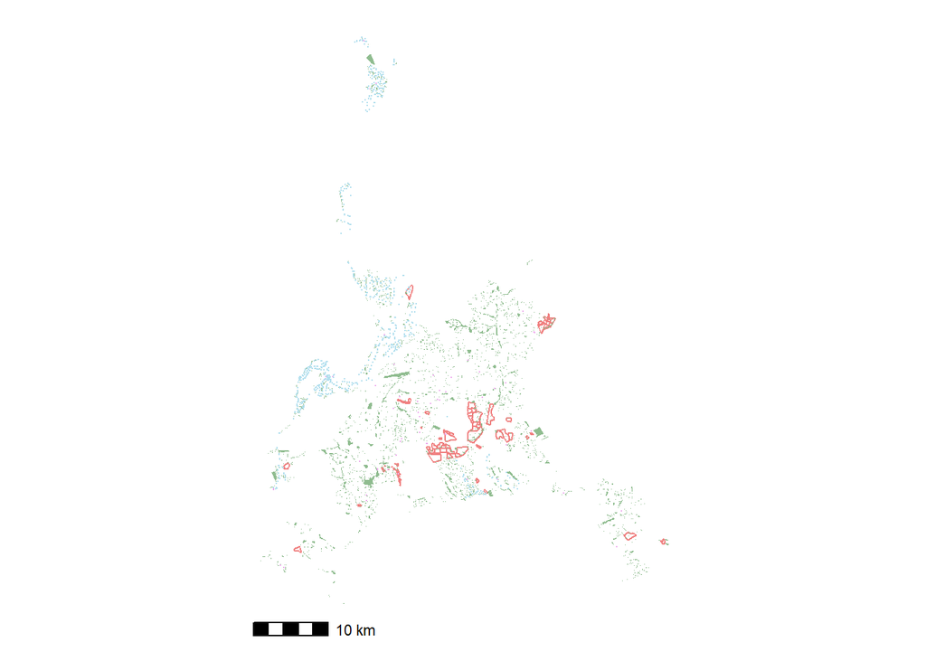

```r
ggplot(township) +
  geom_sf(fill = NA, color = "lightcoral") +
  geom_sf(data = parks, fill = "darkseagreen", color = NA) +
  geom_sf(data = busstop, color = "plum2", size = 0.1) +
  geom_sf(data = office, color = "lightblue2", size = 0.003) +
  theme_map() +
  annotation_scale()
```